# CS 422: Homework #2

Tiffany Wong, Illinois Institute of Technology

### Part 1-A

```r
# read in the us-covid.deaths.csv into a dataframe
df <- read.csv("/Users/tiffwong/Desktop/cs422/hw/hw 2/us-covid-deaths.csv")

# get rid of all rows that contain NA and only keep the complete rows
df_complete <- df[complete.cases(df), ]

# take rows 0 to 6 from the df
print.data.frame(df_complete[0:6, ])
```

```
          date total_deaths icu_patients hosp_patients stringency_index reproduction_rate total_tests positive_rate
176 2020-07-15       137927         9245         33755            68.98              1.15    50115840         0.069
177 2020-07-16       138879         9797         38532            68.98              1.13    51144711         0.070
178 2020-07-17       139803        10700         40057            68.98              1.11    52191692         0.071
179 2020-07-18       140660        10963         40372            68.98              1.10    53103902         0.070
180 2020-07-19       141145        10271         37895            68.98              1.09    53822020         0.070
181 2020-07-20       141707        11291         41136            67.13              1.07    54729376         0.071
```

### Part 1-B

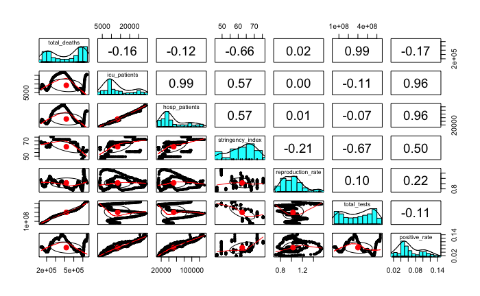

```r
library(psych)
# using on pairs.panels() to create correlation plot with three columns: phd, s.f.ratio, grad rate
pairs.panels(df_complete[ , c('total_deaths', 'icu_patients', 'hosp_patients', 'stringency_index', 'reproduction_rate', 'total_tests', 'positive_rate')])
```

#### Part 1-B (i)

The response variable (total_deaths) has the highest positive correlation with the predictor total_tests, where the correlation coefficient is 0.99.

#### Part 1-B (ii)

The response variable (total_deaths) has the highest negative correlation with the predictor stringency_index, where the correlation coefficient is -0.66.

#### Part 1-B (iii)

There is a high positive correlation between total deaths and total tests, but I don’t think it’s because more tests causes more deaths, but as the COVID-19 pandemic was happening, both number of tests and number of deaths were increasing as time passed. So there seems to be a high correlation between the two, but it’s most likely just more people getting tested while previously positive-tested people were dying. One factor is not the main causation factor of the other. On the other hand, there is a high negative correlation between total deaths and stringency index. The stringency index is the 9 response indicators that will evaluate how the government is responding to COVID. It makes sense that the two factors have an inverse relationship because it means that the higher the stringency index is, the lower the total deaths. This makes sense because the higher the stringency index, the higher the safety measures being taken to ensure that people are social distancing, so people are being more careful around one another and grouping less in social settings. I can’t say that the stringency index is the sole reason why the number of total deaths will increase or decrease, but it’s something to consider that inversely impacts it.

### Part 1-C

```r
# get rid of date column
df_complete = df_complete[ , c('total_deaths', 'icu_patients', 'hosp_patients', 'stringency_index', 'reproduction_rate', 'total_tests', 'positive_rate')]

# perform linear regression fo all parameters against total_deaths
model <- lm(total_deaths ~ ., data=df_complete)

# print out the summary of the model
summary(model)
```

```
Call:
lm(formula = total_deaths ~ ., data = df_complete)

Residuals:
   Min     1Q Median     3Q    Max
-40740  -9846   -371  11709  32843

Coefficients:
                    Estimate Std. Error t value Pr(>|t|)
(Intercept)        8.180e+04  1.597e+04   5.122 4.67e-07 ***
icu_patients      -6.830e+00  9.623e-01  -7.097 5.64e-12 ***
hosp_patients      1.911e-01  2.185e-01   0.875    0.382
stringency_index   1.554e+03  2.106e+02   7.378 9.00e-13 ***
reproduction_rate -9.915e+04  7.008e+03 -14.147  < 2e-16 ***
total_tests        1.203e-03  9.290e-06 129.518  < 2e-16 ***
positive_rate      9.217e+05  1.578e+05   5.841 1.06e-08 ***
---
Signif. codes:  0 ‘***’ 0.001 ‘**’ 0.01 ‘*’ 0.05 ‘.’ 0.1 ‘ ’ 1

Residual standard error: 15700 on 410 degrees of freedom
Multiple R-squared:  0.9922,    Adjusted R-squared:  0.992
F-statistic:  8650 on 6 and 410 DF,  p-value: < 2.2e-16
```

### Part 1-D

Using the summary of the model, this is indeed a good linear regression model by looking at the F-statistic given in the summary of the model. If there is no relationship between response and predictors, F-statistic is close to 1. The p-value associate with the F-statistic is very small, giving me strong evidence that one of th predictors is associated with increased total deaths. Also, the R-squared value is 0.9922, and with r-squared meaning variation divided by total variation, this means that this linear regression model explains 99.22% of total variability. And then I have the adjusted R-value, which takes into account all the predictors. In a model, when an adjusted R-squared value begins to decrease from the original r-squared value, that means the model has enough predictors. The adjusted r-squared value is high, so this linear regression model is good.

### Part 1-E

Using the summary of the model, to see if a predictor is statistically significant, I have to look at the p-value of the predictors in the contest of the following hypothesis test: If p-value is equal to 0, there is no relationship between predictor and response variable and if p-value if not equal to 0, there is some relationship between predictor and response variable. The p-values for icu_patients, stringency_index, reproduction_rate, total_tests, and positive rate appear to imply that there is a relationship between these predictors and total_deaths because the p-value is low. The p-value for hosp_patients appears to imply that there may not be a relationship between hospital patients and total_deaths as the p-value is not 0, bu the null hypothesis of the two factors having absolutely no effect cannot be rejected.

### Part 1-F

Of all the predictors, there is one that is not statistically significant: hosp_patients = number of hospital patients. I would say that the number of hospital patients is not statistically significant to the total deaths in a hospital because the hospital will most likely continuously being filled with people during the COVID-19 pandemic, so while the number of deaths should theoretically take away from the number of patients, the hospital most likely stays filled up with patients instead of fluctuating in number.

### Part 1-G

```r
# remove total_tests from df_complete
df_complete_1g = df_complete[ , c('total_deaths', 'icu_patients', 'hosp_patients', 'stringency_index', 'reproduction_rate', 'positive_rate')]

# perform linear regression fo all parameters against total_deaths
model <- lm(total_deaths ~ ., data=df_complete_1g)

# print out the summary of the model
summary(model)
```

[output not shown]